# Lab 3

Arlena Wang

9/30/2021

## R Markdown

```r
library(ggplot2)
library(tidyverse)
library(dplyr)
dat <- readxl::read_xls('./GSS.xls')
dat <- dat%>%
  rename(year = 'Gss year for this respondent', happiness = 'General happiness', partyid = 'Political party affiliation', income = 'Total family income', sex = 'Respondents sex', education = 'Highest year of school completed', age = 'Age of respondent', marital = 'Marital status', id = 'Respondent id number', ballot = 'Ballot used for interview')
dat$education <- suppressWarnings(as.numeric(dat$education))
dat$age <- suppressWarnings(as.numeric(dat$age))
```

**1.) Find the average years of education for the respondents with each marital status. Arrange your output in a meaningful order and print. Describe any patterns you find.**

```r
dat%>%
  select(marital, education)%>%
  filter(education<21)%>%
  group_by(marital)%>%
  summarise(education_mean = mean(education), .groups = 'drop')
```

```
## # A tibble: 6 × 2
##   marital       education_mean
##   <chr>                  <dbl>
## 1 Divorced                13.1
## 2 Married                 13.0
## 3 Never married           13.4
## 4 No answer               15.5
## 5 Separated               11.9
## 6 Widowed                 11.2
```

The range for the average years of education for the respondents with each marital status is from 11.2 to 15.5. The lowest education mean is the marital status “widowed” and the highest education mean is the marital status with “no answer”.

**2.) Create a single data frame containing records for the better educated respondents with each marital status. A “better educated” respondent is someone who has strictly more years of education than the average among those with the same marital status. Print the structure of the data frame.**

```r
dat%>%
  select(marital, education)%>%
  filter(education>16)%>%
  group_by(marital)
```

```
## # A tibble: 6,710 × 2
## # Groups:   marital [6]
##    marital       education
##    <chr>             <dbl>
##  1 Married              17
##  2 Married              17
##  3 Married              17
##  4 Married              20
##  5 Never married        18
##  6 Married              17
##  7 Never married        18
##  8 Separated            18
##  9 Never married        18
## 10 Never married        19
## # … with 6,700 more rows
```

**3.) How is the happiness of a respondent related to his/her marriage status? Define that a person is happy if the response to question is “Very happy” or “Pretty happy”.**

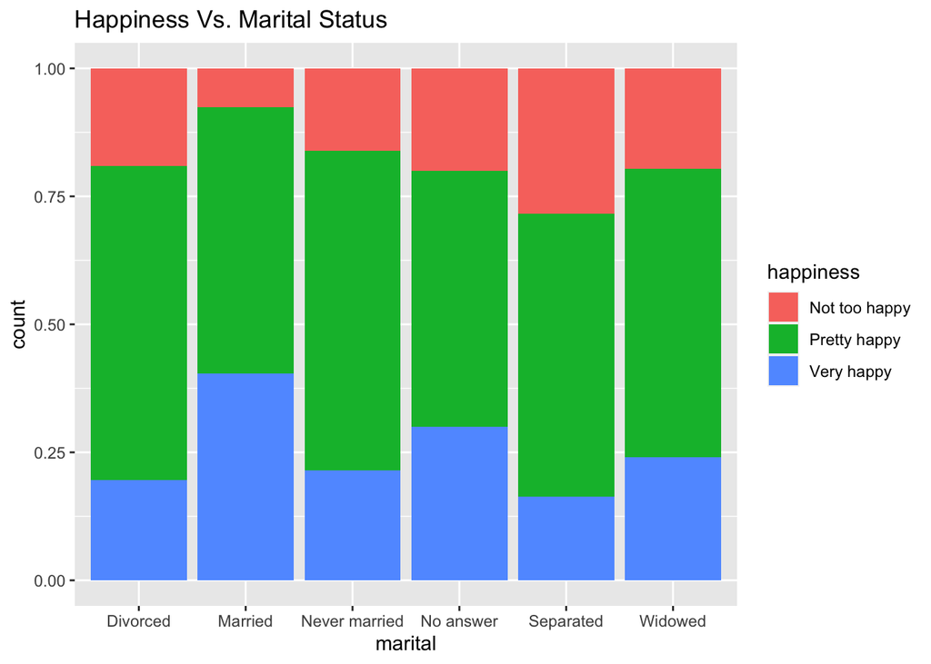

```r
dat%>%
  select(happiness, marital)%>%
  filter(happiness %in% c('Very happy', 'Pretty happy', 'Not too happy')) %>%
  mutate(HappyOrNot = (happiness %in% c('Very happy', 'Pretty happy'))) %>%
  select(happiness, HappyOrNot, marital)%>%
  ggplot(aes(x=marital, fill = happiness)) + geom_bar(position = 'fill') + labs(title = "Happiness Vs. Marital Status")
```

**4.) Does party affiliation affect the relationship you found in the last question?**

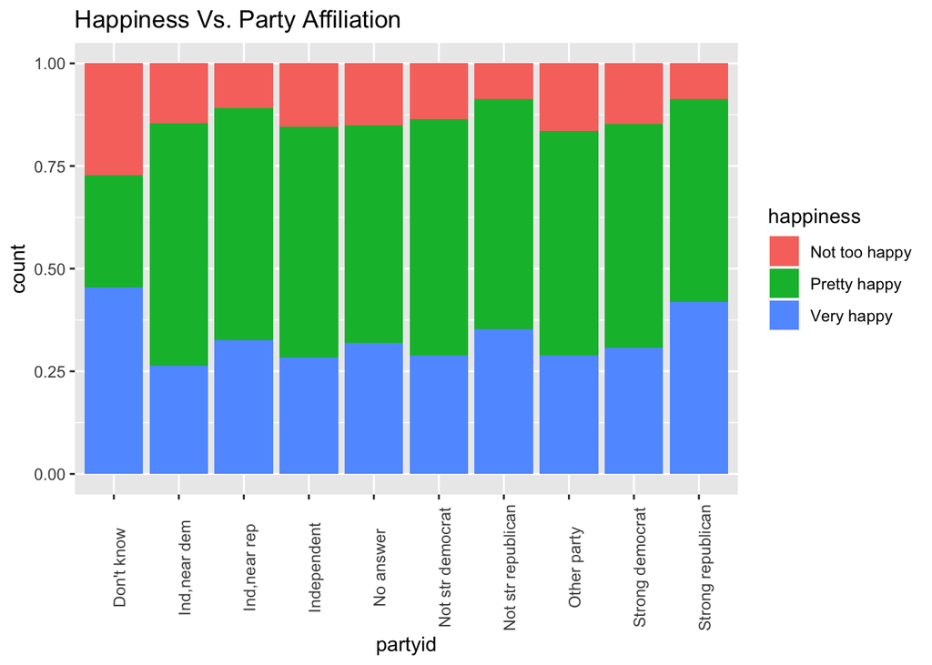

```r
dat%>%
  select(happiness, partyid)%>%
  filter(happiness %in% c('Very happy', 'Pretty happy', 'Not too happy')) %>%
  mutate(HappyOrNot = (happiness %in% c('Very happy', 'Pretty happy'))) %>%
  select(happiness, HappyOrNot, partyid)%>%
  ggplot(aes(x=partyid, fill = happiness)) + geom_bar(position = 'fill') + labs(title = "Happiness Vs. Party Affiliation") + theme(axis.text.x = element_text(angle = 90))
```

**5.) Explore an interesting question (not covered by the previous questions), and answer the question using the GSS data.**

Does sex affect level of happiness? How does sex predict happiness?

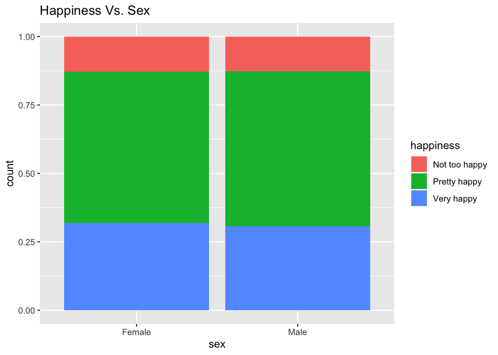

```r
dat%>%
  select(happiness, sex)%>%
  filter(happiness %in% c('Very happy', 'Pretty happy', 'Not too happy')) %>%
  mutate(HappyOrNot = (happiness %in% c('Very happy', 'Pretty happy'))) %>%
  select(happiness, HappyOrNot, sex)%>%
  ggplot(aes(x=sex, fill = happiness)) + geom_bar(position = 'fill') + labs(title = "Happiness Vs. Sex")
```

No, because the levels of happiness are the almost the same for both sexes, female and male, this shows that sex does not affect the level of happiness. Both sexes have the same level of happiness if “pretty happy” and “Very happy” are considered “happy” and “not too happy” is considered “unhappy.” Therefore, females and males have the same levels of happiness or unhappiness. The females column shows that they are slightly more “very happy” and slightly less “pretty happy” than men. Overall, due to no difference under the conditions, happiness does not depend on Sex.